# IML_Week_4_Assignment_Anand_rj

## Objective

This homework sheet will help reviewing the basic concepts associated with classification models. Please review the lectures, suggested readings, and additional resources before getting started on the HW.

**Some questions in this assignment will require you to conduct independent research beyond the material covered in the recorded content.**

**Questions**

This homework is divided into two main parts. First, a conceptual component will review the basic concepts related to classification models. The second part of the homework is mostly intended to be a brief introduction to fitting and analyzing classifiers in `Python`. Several of these questions are modified from James et al. (2021).

Marks Distribution

| Question | Marks |
| --- | --- |
| 1a | 0.25 |
| 1b | 0.25 |
| 1c | 0.25 |
| 1d | 0.25 |
| 2a | 0.50 |
| 2b | 0.50 |
| 3 | 1 |
| 4a | 1 |
| 4b | 1 |
| 4c | 0.5 |
| 4d | 1 |
| 4e | 1 |
| 4f | 1 |
| 4g | 0.25 |
| 4h | 0.25 |
| 5a | 1 |
| 5b | 1 |
| 5c | 1 |
| 5d | 1 |
| 5e | 1 |
| 5f | 1 |

## Conceptual Questions

### Q1. Let’s examine the differences between LDA and QDA.

#### a) If the Bayes decision boundary is linear, do we expect LDA or QDA to perform better on the training set? What about in the test set?

Answer:

QDA might perform better on training data due to flexibility. However, if the actual boundary between classes is linear also LDA would be better for the new data as QDA may overfit to the training data and possibly not perform well with new information.

#### b) If the Bayes decision boundary is non-linear, do we expect LDA or QDA to perform better on the training set? On the test set?

Answer:

When the true class separation curve deviates from a straight line to a curve or a more complex shape, I would expect QDA to perform better on both training and test sets. This is because of its ability to adapt to different covariance matrices for each class and thus QDA would be advantageous when the decision boundary is non-linear.

#### c)In general, as the sample size n increases, do we expect the test prediction accuracy of QDA relative to LDA to improve, decline, or be unchanged? Why?

Answer:

When the sample size (n) As n rises, we have reason to believe QDA’s tests will exceed LDA’s in the precision of their predictions. This is generally the case when a larger n allows more flexible methods like QDA to fit the data better. This tendency will be robust as long as the larger dataset compensates for the variability in scenarios associated with increased flexibility.

#### d)True or False:

Even if the Bayes decision boundary for a given problem is linear, we will probably achieve a superior test error rate using QDA rather than LDA because QDA is flexible enough to model a linear decision boundary.

Answer:

False. When the true decision boundary is a straight line Linear Discriminant Analysis (LDA) is expected to perform equally well as, or potentially better than Quadratic Discriminant Analysis (QDA) regarding the test error rate.

### Q2) In relation to the odds and the Default dataset

#### a) On average, what fraction of people with an odds of `0.37` of defaulting on their credit card payment will in fact default?

```python
# BEGIN SOLUTION
people_odds = 0.37
probability = people_odds/(1+people_odds)
probability
# END SOLUTION
```

```
0.27007299270072993
```

27% of the people with odds of 0.37 of defaulting their credit card payment will in fact default

#### b) Suppose that an individual has a `16%` chance of defaulting on their credit card payment. What are the odds that they will default?

```python
# BEGIN SOLUTION
probability = 0.16
odds = probability/(1-probability)
odds
# END SOLUTION
```

```
0.1904761904761905
```

Answer:

0.1904 Odds that an individual will default on their credit card payment.

#### Q3. Suppose that we take a data set, divide it into equally sized training and test sets, and then try out two different classification procedures. First, we use logistic regression and get an error rate of `20%` on the training data and `30%` on the test data. Next we use 1-nearest neighbors (i.e. `K=1`) and get an average error rate (averaged over both test and training data sets) of `18%`. Based on these results, which method should we prefer to use for classification of new observations? Why?

Answer:

Opt for the 1-Nearest Neighbors method (K=1) when classifying new observations as it demonstrates superior performance overall with an average error rate of 18% in contrast to logistic regression which exhibits a higher test error rate of 30%. This indicates that KNN is more adept at generalizing to new unseen data.

## Applied

#### 4) This question should be answered using the `Weekly` data set, which is part of the `ISLR2` package. This data is similar in nature to the `Smarket` data examined in the book (Ch4, lab). First, load the dataset:

https://book.huihoo.com/introduction-to-statistical-learning/data.html

Link for getting rdataset into python: https://www.statsmodels.org/dev/datasets/statsmodels.datasets.get_rdataset.html

By using the below command you can get the ISLR dataset `sm.datasets.get_rdataset('Weekly', 'ISLR').data`

#### a) Produce some numerical and graphical summaries of the `Weekly` data. Can you identify any patterns? Hint: examine the **correlation** between predictors.

**Importing Libraries:**

```python
#IMPORT LIBRARIES
import seaborn as sns
import pandas as pd
import matplotlib.pyplot as plt
import numpy as np
import statsmodels.api as sm
from sklearn.compose import ColumnTransformer
from sklearn.linear_model import LogisticRegression
from sklearn.metrics import confusion_matrix
from sklearn.preprocessing import OneHotEncoder
from sklearn.neighbors import KNeighborsClassifier
from sklearn.model_selection import train_test_split
from sklearn.pipeline import Pipeline
from sklearn.discriminant_analysis import LinearDiscriminantAnalysis,QuadraticDiscriminantAnalysis
```

**Loading dataset:**

```python
#READ Weekly DATASET USING THE CODE GIVEN IN QUESTION 4

weekly_data = sm.datasets.get_rdataset('Weekly', 'ISLR').data
weekly_data.head()
```

|  | Year | Lag1 | Lag2 | Lag3 | Lag4 | Lag5 | Volume | Today | Direction |
| --- | --- | --- | --- | --- | --- | --- | --- | --- | --- |
| 0 | 1990 | 0.816 | 1.572 | -3.936 | -0.229 | -3.484 | 0.154976 | -0.270 | Down |
| 1 | 1990 | -0.270 | 0.816 | 1.572 | -3.936 | -0.229 | 0.148574 | -2.576 | Down |
| 2 | 1990 | -2.576 | -0.270 | 0.816 | 1.572 | -3.936 | 0.159837 | 3.514 | Up |
| 3 | 1990 | 3.514 | -2.576 | -0.270 | 0.816 | 1.572 | 0.161630 | 0.712 | Up |
| 4 | 1990 | 0.712 | 3.514 | -2.576 | -0.270 | 0.816 | 0.153728 | 1.178 | Up |

```python
#PERFORM PRE PROCESSING OF DATA IF REQUIRED ( OBSERVE THE DATASET AND ITS VALUES CAREFULLY)
weekly_data.describe()
```

|  | Year | Lag1 | Lag2 | Lag3 | Lag4 | Lag5 | Volume | Today |
| --- | --- | --- | --- | --- | --- | --- | --- | --- |
| count | 1089.000000 | 1089.000000 | 1089.000000 | 1089.000000 | 1089.000000 | 1089.000000 | 1089.000000 | 1089.000000 |
| mean | 2000.048669 | 0.150585 | 0.151079 | 0.147205 | 0.145818 | 0.139893 | 1.574618 | 0.149899 |
| std | 6.033182 | 2.357013 | 2.357254 | 2.360502 | 2.360279 | 2.361285 | 1.686636 | 2.356927 |
| min | 1990.000000 | -18.195000 | -18.195000 | -18.195000 | -18.195000 | -18.195000 | 0.087465 | -18.195000 |
| 25% | 1995.000000 | -1.154000 | -1.154000 | -1.158000 | -1.158000 | -1.166000 | 0.332022 | -1.154000 |
| 50% | 2000.000000 | 0.241000 | 0.241000 | 0.241000 | 0.238000 | 0.234000 | 1.002680 | 0.241000 |
| 75% | 2005.000000 | 1.405000 | 1.409000 | 1.409000 | 1.409000 | 1.405000 | 2.053727 | 1.405000 |
| max | 2010.000000 | 12.026000 | 12.026000 | 12.026000 | 12.026000 | 12.026000 | 9.328214 | 12.026000 |

```python
# BEGIN SOLUTION
weekly_data['Direction'].value_counts()
# END SOLUTION
```

```
Direction
Up      605
Down    484
Name: count, dtype: int64
```

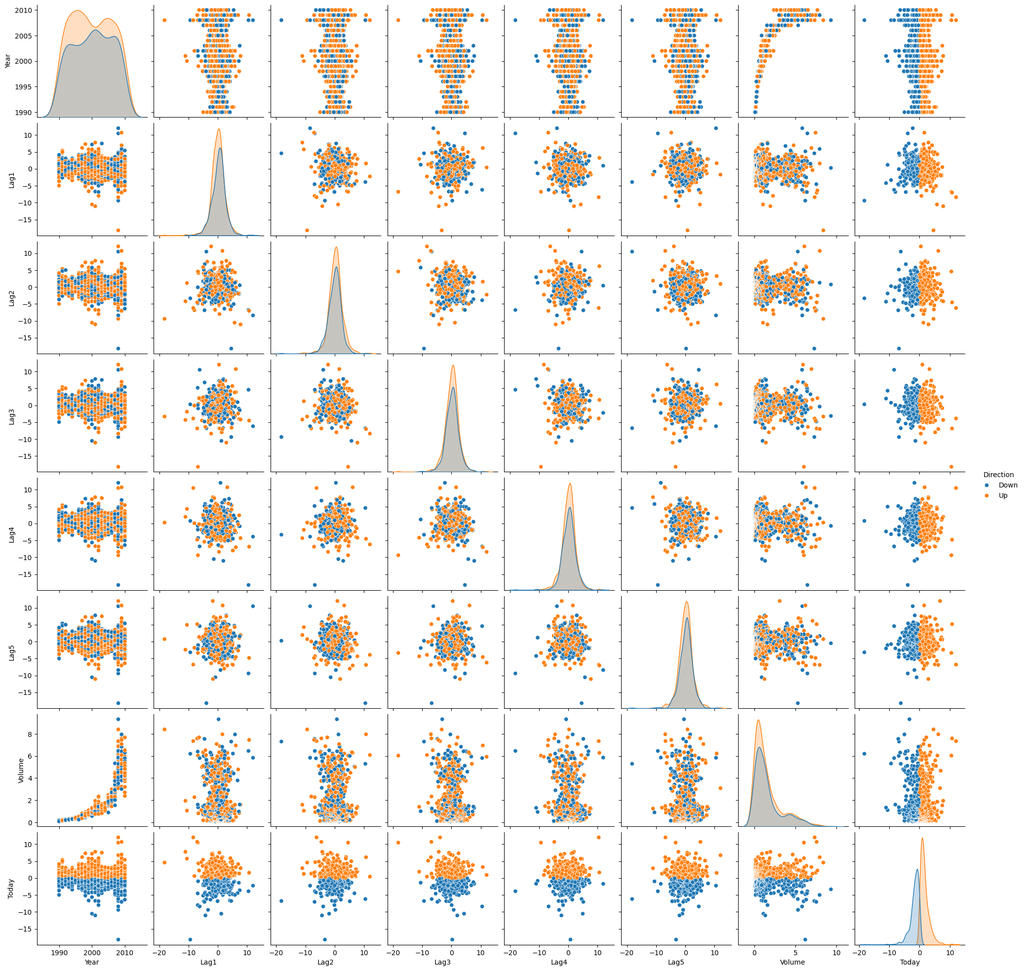

```python
# BEGIN SOLUTION
sns.pairplot(weekly_data, hue='Direction')
# END SOLUTION
```

You can refer to the `seaborn` library documentation to attempt this problem: https://seaborn.pydata.org/

#### b) Use the full data set to perform a logistic regression with Direction as the response and the five `lag` variables plus `Volume` as predictors. Use the summary function to print the results. Do any of the predictors appear to be statistically significant? If so, which ones? Use the statsmodels to construct the classifier.

Link: https://www.statsmodels.org/

```python
#BEGIN SOLUTION
response = (weekly_data['Direction'] == 'Up').astype('int64')
predictors = sm.add_constant(weekly_data.drop(columns=['Direction', 'Year', 'Today']))
logit_model = sm.Logit(response, predictors)
logit_results = logit_model.fit()
logit_results.summary()
# END SOLUTION
```

```
Optimization terminated successfully.
         Current function value: 0.682441
         Iterations 4
```

Logit Regression Results

| Dep. Variable: | Direction | No. Observations: | 1089 |
| --- | --- | --- | --- |
| Model: | Logit | Df Residuals: | 1082 |
| Method: | MLE | Df Model: | 6 |
| Date: | Wed, 17 Apr 2024 | Pseudo R-squ.: | 0.006580 |
| Time: | 05:44:44 | Log-Likelihood: | -743.18 |
| converged: | True | LL-Null: | -748.10 |
| Covariance Type: | nonrobust | LLR p-value: | 0.1313 |

|  | coef | std err | z | P>\|z\| | [0.025 | 0.975] |
| --- | --- | --- | --- | --- | --- | --- |
| const | 0.2669 | 0.086 | 3.106 | 0.002 | 0.098 | 0.435 |
| Lag1 | -0.0413 | 0.026 | -1.563 | 0.118 | -0.093 | 0.010 |
| Lag2 | 0.0584 | 0.027 | 2.175 | 0.030 | 0.006 | 0.111 |
| Lag3 | -0.0161 | 0.027 | -0.602 | 0.547 | -0.068 | 0.036 |
| Lag4 | -0.0278 | 0.026 | -1.050 | 0.294 | -0.080 | 0.024 |
| Lag5 | -0.0145 | 0.026 | -0.549 | 0.583 | -0.066 | 0.037 |
| Volume | -0.0227 | 0.037 | -0.616 | 0.538 | -0.095 | 0.050 |

```python
# BEGIN SOLUTION
parameter_summary = pd.DataFrame({
    'Estimate': logit_results.params,
    'Std.Error': logit_results.bse,
    'Z value': logit_results.tvalues,
    'Pr(>|Z|)': logit_results.pvalues
})

parameter_summary
# END SOLUTION
```

|  | Estimate | Std.Error | Z value | Pr(>\|Z\|) |
| --- | --- | --- | --- | --- |
| const | 0.266864 | 0.085930 | 3.105613 | 0.001899 |
| Lag1 | -0.041269 | 0.026410 | -1.562610 | 0.118144 |
| Lag2 | 0.058442 | 0.026865 | 2.175384 | 0.029601 |
| Lag3 | -0.016061 | 0.026663 | -0.602376 | 0.546924 |
| Lag4 | -0.027790 | 0.026463 | -1.050141 | 0.293653 |
| Lag5 | -0.014472 | 0.026385 | -0.548501 | 0.583348 |
| Volume | -0.022742 | 0.036898 | -0.616333 | 0.537675 |

The examination reveals that among the predictors, only Lag2 demonstrates statistical significance concerning the response variable "Direction." The p-value corresponding to Lag2 is 0.0296, indicating evidence at the 5% significance level to reject the null hypothesis indicating a notable relationship with the response. None of the other predictors exhibit statistically significant correlations. While Lag1 nears significance at the 10% level with a p-value of 0.1181 it does not meet the 5% threshold for substantial evidence of a relationship with the response variable.

#### C) Compute the confusion matrix and overall fraction of correct predictions. Explain what the confusion matrix is telling you about the types of mistakes made by logistic regression.

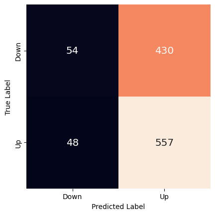

```python
# BEGIN SOLUTION
confusion_matrix_df = pd.DataFrame(logit_results.pred_table(), columns=["Down", "Up"], index=["Down", "Up"])
fig, ax = plt.subplots()
sns.heatmap(confusion_matrix_df, annot=True, cbar=False, ax=ax, fmt="g", square=True, annot_kws={"fontsize": "x-large"})
ax.set(xlabel="Predicted Label", ylabel="True Label")
plt.show()

# END SOLUTION
```

```python
# BEGIN SOLUTION
predictions = pd.Series(logit_results.predict()).apply(lambda x: "Up" if (x > 0.5) else "Down")
accuracy = (predictions == weekly_data["Direction"]).mean()
accuracy

# END SOLUTION
```

```
0.5610651974288338
```

**Observations:**

The logistic regression model with lag variables and Volume as predictors and a prediction threshold of 0.5 has an accuracy rate of 56.11%. This rate is above random chance. However, it should be noted that because the model was trained on the entire dataset, this can be misleading. Similarly, from the above confusion matrix, the true positive rate is 92% and has a positive predictive value of about 56.4 . Nevertheless, if every week was predicted as an up week, we would have a positive predictive value. This means that the model has a negative predictive value of approximately 52.9 , which implies that the model can predict down weeks. Hence this model is also misan ideal and considering what one is striving to achieve with that model in the first place.

#### d) Now fit the logistic regression model using a training data period from **1990 to 2008**, with `Lag2` as the only predictor. Compute the confusion matrix and the overall fraction of correct predictions for the held out data (that is, the data from **2009 and 2010**).

```python
# BEGIN SOLUTION
training_mask = (weekly_data['Year'] < 2009)
train_response = (weekly_data.loc[training_mask, "Direction"] == "Up").astype("int64")
train_predictors = sm.add_constant(weekly_data.loc[training_mask, "Lag2"])
logit_model_train = sm.Logit(train_response, train_predictors)
logit_results_train = logit_model_train.fit()
logit_results_train.summary()
# END SOLUTION
```

```
Optimization terminated successfully.
         Current function value: 0.685555
         Iterations 4
```

Logit Regression Results

| Dep. Variable: | Direction | No. Observations: | 985 |
| --- | --- | --- | --- |
| Model: | Logit | Df Residuals: | 983 |
| Method: | MLE | Df Model: | 1 |
| Date: | Wed, 17 Apr 2024 | Pseudo R-squ.: | 0.003076 |
| Time: | 05:46:14 | Log-Likelihood: | -675.27 |
| converged: | True | LL-Null: | -677.35 |
| Covariance Type: | nonrobust | LLR p-value: | 0.04123 |

|  | coef | std err | z | P>\|z\| | [0.025 | 0.975] |
| --- | --- | --- | --- | --- | --- | --- |
| const | 0.2033 | 0.064 | 3.162 | 0.002 | 0.077 | 0.329 |
| Lag2 | 0.0581 | 0.029 | 2.024 | 0.043 | 0.002 | 0.114 |

```python
# BEGIN SOLUTION
test_predictors = sm.add_constant(weekly_data.loc[~training_mask, "Lag2"])
test_response = weekly_data.loc[~training_mask, "Direction"]
logit_test_probs = logit_results_train.predict(test_predictors)
logit_test_predictions = pd.Series(logit_test_probs).apply(lambda x: "Up" if (x > 0.5) else "Down")
# END SOLUTION
```

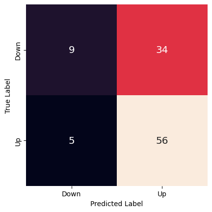

```python
#BEGIN SOLUTION
confusion_matrix_df = pd.DataFrame(confusion_matrix(test_response, logit_test_predictions), columns=["Down", "Up"], index=["Down", "Up"])
fig, ax = plt.subplots()
sns.heatmap(confusion_matrix_df, annot=True, cbar=False, ax=ax, fmt="g", square=True, annot_kws={"fontsize": "x-large"})
ax.set(xlabel="Predicted Label", ylabel="True Label")
plt.show()
#END SOLUTION
```

```python
accuracy_test = (logit_test_predictions == weekly_data.loc[~training_mask, "Direction"]).mean()
accuracy_test
```

```
0.625
```

After training on data from 1990 to 2008 and then testing on data from 2009 and 201, the logistic regression model achieved a 62.5% accuracy rate in predicting market direction for weeks. Although this performance is superior to chance it represents only a modest enhancement over a straightforward strategy. Notable metrics from the model include a true positive rate of 91.8% a false positive rate of 79.1%, a positive predictive value of 62.2% and a negative predictive value of 64.3%.

#### e)Repeat (d) using LDA.

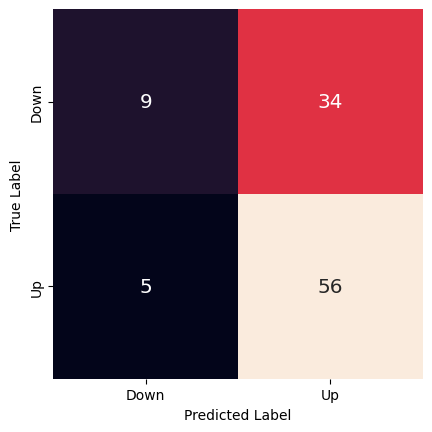

```python
# BEGIN SOLUTION
training_data_mask = (weekly_data['Year'] < 2009)
X_train_alt = weekly_data.loc[training_data_mask, "Lag2"].to_frame()
y_train_alt = weekly_data.loc[training_data_mask, "Direction"]
X_test_alt = weekly_data.loc[~training_data_mask, "Lag2"].to_frame()
y_test_alt = weekly_data.loc[~training_data_mask, "Direction"]
lda_classifier = LinearDiscriminantAnalysis()
lda_classifier.fit(X_train_alt, y_train_alt)
y_pred_alt = lda_classifier.predict(X_test_alt)
confusion_matrix_alt = confusion_matrix(y_test_alt, y_pred_alt)
fig, ax = plt.subplots()
sns.heatmap(confusion_matrix_alt, annot=True, cbar=False, ax=ax, fmt="g", square=True, annot_kws={"fontsize": "x-large"},
           xticklabels=lda_classifier.classes_, yticklabels=lda_classifier.classes_)
ax.set(xlabel="Predicted Label", ylabel="True Label")
plt.show()

# END SOLUTION
```

```python
# BEGIN SOLUTION
accuracy_lda_alt = lda_classifier.score(X_test_alt, y_test_alt)
accuracy_lda_alt
# END SOLUTION
```

```
0.625
```

Using Lag2 as the sole predictor, linear discriminant analysis was applied to data spanning from 1990 to 2008. The model's performance, reflected in the confusion matrix mirrors that of the logistic regression model discussed in Part 4. It successfully predicted market direction for 62.5% of weeks in the 2009 and 2010 dataset. This improvement over random guessing is marginal, less than 10%. The true positive rate stands at 91.8% signifying precise identification of positive weeks while the false positive rate reaches 79.1% denoting instances of inaccurate positive predictions.

#### f) Repeat (d) using QDA.

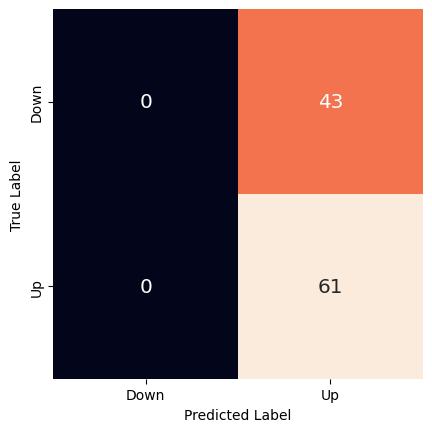

```python
# BEGIN SOLUTION
training_data_mask = (weekly_data['Year'] < 2009)
X_train_alt = weekly_data.loc[training_data_mask, "Lag2"].to_frame()
y_train_alt = weekly_data.loc[training_data_mask, "Direction"]
X_test_alt = weekly_data.loc[~training_data_mask, "Lag2"].to_frame()
y_test_alt = weekly_data.loc[~training_data_mask, "Direction"]
qda_classifier = QuadraticDiscriminantAnalysis()
qda_classifier.fit(X_train_alt, y_train_alt)
y_pred_alt = qda_classifier.predict(X_test_alt)
confusion_matrix_alt = confusion_matrix(y_test_alt, y_pred_alt)
fig, ax = plt.subplots()
sns.heatmap(confusion_matrix_alt, annot=True, cbar=False, ax=ax, fmt="g", square=True, annot_kws={"fontsize": "x-large"},
           xticklabels=qda_classifier.classes_, yticklabels=qda_classifier.classes_)
ax.set(xlabel="Predicted Label", ylabel="True Label")
plt.show()
# END SOLUTION
```

```python
# BEGIN SOLUTION
accuracy_qda_alt = qda_classifier.score(X_test_alt, y_test_alt)
accuracy_qda_alt
# END SOLUTION
```

```
0.5865384615384616
```

The quadratic discriminant analysis (QDA) model using Lag2 as the predictor forecasted that every week in 2009 and 2010 would be an up week. This resulted in a 58.7% accuracy comparable to simply predicting all weeks as up weeks. To comprehensively assess its performance against other models testing on a larger dataset would be necessary. The model achieved a true positive rate of 100%, a false positive rate of 100% and a positive predictive value of 58.7%. Since there were no negative predictions, discussing the negative predictive value is not relevant.

#### g) Repeat (d) using KNN with K=1

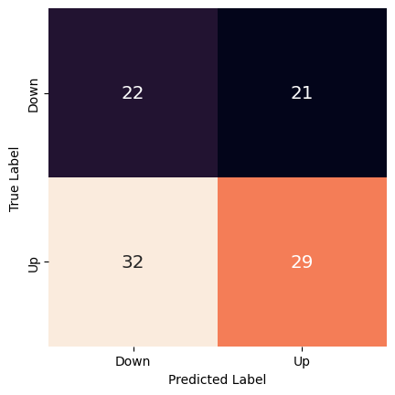

```python
# BEGIN SOLUTION
training_data_mask = (weekly_data['Year'] < 2009)

X_train_alt = weekly_data.loc[training_data_mask, "Lag2"].to_frame()
y_train_alt = weekly_data.loc[training_data_mask, "Direction"]

X_test_alt = weekly_data.loc[~training_data_mask, "Lag2"].to_frame()
y_test_alt = weekly_data.loc[~training_data_mask, "Direction"]

np.random.seed(312)

knn_1_classifier = KNeighborsClassifier(n_neighbors=1)
knn_1_classifier.fit(X_train_alt, y_train_alt)

y_pred_alt = knn_1_classifier.predict(X_test_alt)

confusion_matrix_alt = confusion_matrix(y_test_alt, y_pred_alt)

fig, ax = plt.subplots()
sns.heatmap(confusion_matrix_alt, annot=True, cbar=False, ax=ax, fmt="g", square=True, annot_kws={"fontsize": "x-large"},
           xticklabels=knn_1_classifier.classes_, yticklabels=knn_1_classifier.classes_)
ax.set(xlabel="Predicted Label", ylabel="True Label")
plt.show()
# END SOLUTION
```

```python
# BEGIN SOLUTION
accuracy_knn_1_alt = knn_1_classifier.score(X_test_alt, y_test_alt)
accuracy_knn_1_alt
# END SOLUTION
```

```
0.49038461538461536
```

### 5) Develop a model to predict whether a given car gets high or low gas mileage based on the `Auto` data set. Load the dataset:

```python
# BEGIN SOLUTION
#Load dataset
auto_data = sm.datasets.get_rdataset('Auto', 'ISLR').data
auto_data.head()
# END SOLUTION
```

| rownames | mpg | cylinders | displacement | horsepower | weight | acceleration | year | origin | name |
| --- | --- | --- | --- | --- | --- | --- | --- | --- | --- |
| 1 | 18.0 | 8 | 307.0 | 130 | 3504 | 12.0 | 70 | 1 | chevrolet chevelle malibu |
| 2 | 15.0 | 8 | 350.0 | 165 | 3693 | 11.5 | 70 | 1 | buick skylark 320 |
| 3 | 18.0 | 8 | 318.0 | 150 | 3436 | 11.0 | 70 | 1 | plymouth satellite |
| 4 | 16.0 | 8 | 304.0 | 150 | 3433 | 12.0 | 70 | 1 | amc rebel sst |
| 5 | 17.0 | 8 | 302.0 | 140 | 3449 | 10.5 | 70 | 1 | ford torino |

```python
# BEGIN SOLUTION
auto_data["origin"] = auto_data["origin"].map({1: "American", 2: "European", 3: "Japanese"})
auto_data.head()
# END SOLUTION
```

| rownames | mpg | cylinders | displacement | horsepower | weight | acceleration | year | origin | name |
| --- | --- | --- | --- | --- | --- | --- | --- | --- | --- |
| 1 | 18.0 | 8 | 307.0 | 130 | 3504 | 12.0 | 70 | American | chevrolet chevelle malibu |
| 2 | 15.0 | 8 | 350.0 | 165 | 3693 | 11.5 | 70 | American | buick skylark 320 |
| 3 | 18.0 | 8 | 318.0 | 150 | 3436 | 11.0 | 70 | American | plymouth satellite |
| 4 | 16.0 | 8 | 304.0 | 150 | 3433 | 12.0 | 70 | American | amc rebel sst |
| 5 | 17.0 | 8 | 302.0 | 140 | 3449 | 10.5 | 70 | American | ford torino |

a) Create a binary variable, `mpg01`, that contains a `1` if `mpg` contains a value above its median, and a `0` if `mpg` contains a value below its median.Note : you may find it helpful to use the `pd.DataFrame()` function to create a single data set containing both `mpg01` and the other `Auto` variables.

Link to median(): https://pandas.pydata.org/docs/reference/api/pandas.DataFrame.median.html

```python
# BEGIN SOLUTION
mpg01 = (auto_data["mpg"] > auto_data["mpg"].median()).map({False: 0, True: 1})
auto_data["mpg01"] = mpg01
auto_data.head()
# END SOLUTION
```

| rownames | mpg | cylinders | displacement | horsepower | weight | acceleration | year | origin | name | mpg01 |
| --- | --- | --- | --- | --- | --- | --- | --- | --- | --- | --- |
| 1 | 18.0 | 8 | 307.0 | 130 | 3504 | 12.0 | 70 | American | chevrolet chevelle malibu | 0 |
| 2 | 15.0 | 8 | 350.0 | 165 | 3693 | 11.5 | 70 | American | buick skylark 320 | 0 |
| 3 | 18.0 | 8 | 318.0 | 150 | 3436 | 11.0 | 70 | American | plymouth satellite | 0 |
| 4 | 16.0 | 8 | 304.0 | 150 | 3433 | 12.0 | 70 | American | amc rebel sst | 0 |
| 5 | 17.0 | 8 | 302.0 | 140 | 3449 | 10.5 | 70 | American | ford torino | 0 |

#### b) Explore the data graphically in order to investigate the association between `mpg01` and the other features. Which of the other features seem most likely to be useful in predicting `mpg01`? Scatterplots and boxplots may be useful tools to answer this question Describe your findings

Link to Scatter plot: https://seaborn.pydata.org/generated/seaborn.scatterplot.html

Link to Violin plot: https://seaborn.pydata.org/generated/seaborn.violinplot.html

Link to Box plot: https://seaborn.pydata.org/generated/seaborn.boxplot.html

[output not shown]

[output cut: 77 more lines]

[output not shown]

[figure not shown]

```python
# BEGIN SOLUTION
fig, axes = plt.subplots(nrows = 2, ncols = 3, figsize = (16, 12))
sns.distplot(auto_data.loc[auto_data["mpg01"] == 1, "cylinders"], ax = axes[0, 0], color = "red")
sns.distplot(auto_data.loc[auto_data["mpg01"] == 0, "cylinders"], ax = axes[0, 0])
sns.distplot(auto_data.loc[auto_data["mpg01"] == 0, "displacement"], ax = axes[0, 1], color = "red")
sns.distplot(auto_data.loc[auto_data["mpg01"] == 0, "displacement"], ax = axes[0, 1])
sns.distplot(auto_data.loc[auto_data["mpg01"] == 1, "horsepower"], ax = axes[0, 2], color = "red")
sns.distplot(auto_data.loc[auto_data["mpg01"] == 0, "horsepower"], ax = axes[0, 2])
sns.distplot(auto_data.loc[auto_data["mpg01"] == 1, "weight"], ax = axes[1, 0], color = "red")
sns.distplot(auto_data.loc[auto_data["mpg01"] == 0, "weight"], ax = axes[1, 0])
sns.distplot(auto_data.loc[auto_data["mpg01"] == 1, "acceleration"], ax = axes[1, 1], color = "red")
sns.distplot(auto_data.loc[auto_data["mpg01"] == 0, "acceleration"], ax = axes[1, 1])
sns.distplot(auto_data.loc[auto_data["mpg01"] == 1, "year"], ax = axes[1, 2], color = "red")
sns.distplot(auto_data.loc[auto_data["mpg01"] == 0, "year"], ax = axes[1, 2])
fig.suptitle("Histograms and KDE plots for cars with above (red) and below (blue) median mpg",
             size = "xx-large", y = 0.925);
# END SOLUTION
```

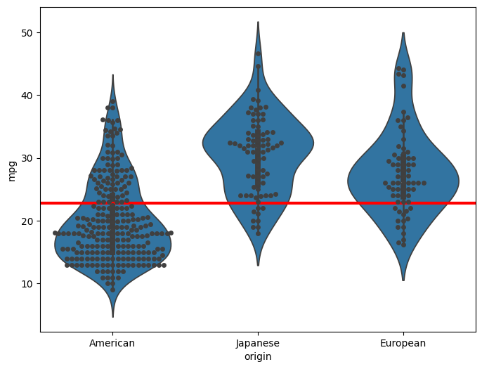

```python
# BEGIN SOLUTION
fig, ax = plt.subplots(figsize = (8, 6))
sns.violinplot(x = "origin", y = "mpg", data = auto_data, ax = ax)
sns.swarmplot(x = "origin", y = "mpg", data = auto_data, ax = ax, color = ".25")
ax.axhline(y = auto_data["mpg"].median(), color = "red", linewidth = 3);
# END SOLUTION
```

The examination uncovers a clear disparity in fuel efficiency between American cars **below-median** and European/Japanese cars **above-median** categorized by their country of origin. Consequently, the origin variable emerges as a valuable predictor for estimating median fuel economy **mpg med**. In upcoming sections, all predictors except acceleration and name will be utilized in models to forecast mpg med, while mpg will be omitted as it was utilized in forming the classification label.

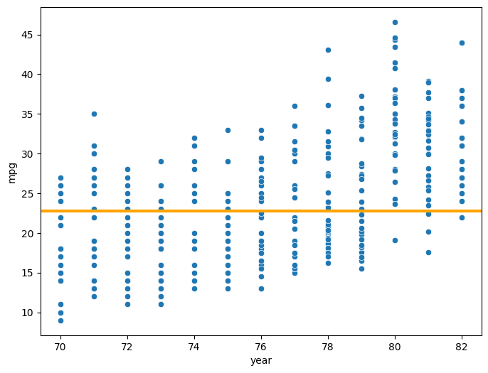

```python
# BEGIN SOLUTION
fig, ax = plt.subplots(figsize = (8, 6))
sns.scatterplot(x = "year", y = "mpg", data = auto_data, ax = ax)
ax.axhline(y = auto_data["mpg"].median(), color = "orange", linewidth = 3);
# END SOLUTION
```

The dataset indicates that newer cars generally exhibit higher fuel efficiency suggesting that the manufacturing year could serve as a potentially useful predictor not as crucial as other major variables.

#### C) Split the data into a training set and a test set (70%, 30%). Use `random.seed(4)` to make the training data reproducible.

Link to linear model: https://scikit-learn.org/stable/modules/generated/sklearn.model_selection.train_test_split.html

```python
# BEGIN SOLUTION
X_train, X_test, y_train, y_test = train_test_split(auto_data, auto_data["mpg01"], test_size = 0.30, random_state = 312)
# END SOLUTION
```

#### d) Perform LDA on the training data in order to predict `mpg01` using the variables that seemed most associated with `mpg01` in (b). What is the test error of the model obtained?

```python
# BEGIN SOLUTION
categorical_features_custom = ["origin"]
categorical_transformer_custom = Pipeline([("onehot", OneHotEncoder(drop="first"))])
numerical_features_custom = ["cylinders", "displacement", "horsepower", "weight", "year"]
preprocessor_custom = ColumnTransformer([("cat", categorical_transformer_custom, categorical_features_custom),
                                         ("num", "passthrough", numerical_features_custom)])
clf_custom = Pipeline([("preprocessor", preprocessor_custom), ("classifier", LinearDiscriminantAnalysis())])
# END SOLUTION
```

```
[Text(0.5, 23.52222222222222, 'predicted label'),
```

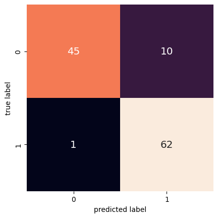

```python
# BEGIN SOLUTION
clf_custom.fit(X_train, y_train)
y_pred_custom = clf_custom.predict(X_test)
mat_custom = confusion_matrix(y_test, y_pred_custom)
fig_custom, ax_custom = plt.subplots()
sns.heatmap(mat_custom, annot=True, cbar=False, ax=ax_custom, fmt="g", square=True, annot_kws={"fontsize": "x-large"},
            xticklabels=clf_custom["classifier"].classes_, yticklabels=clf_custom["classifier"].classes_)
ax_custom.set(xlabel="predicted label", ylabel="true label")
# END SOLUTION
```

```python
# BEGIN SOLUTION
1 - clf_custom.score(X_test, y_test)
# END SOLUTION
```

```
0.09322033898305082
```

```python
# BEGIN SOLUTION
#Year and origin column not included
categorical_features_custom = []
categorical_transformer_custom = Pipeline([("onehot", OneHotEncoder(drop="first"))])
numerical_features_custom = ["cylinders", "displacement", "horsepower", "weight"]
preprocessor_custom = ColumnTransformer([("cat", categorical_transformer_custom, categorical_features_custom),
                                         ("num", "passthrough", numerical_features_custom)])
clf_custom = Pipeline([("preprocessor", preprocessor_custom), ("classifier", LinearDiscriminantAnalysis())])
# END SOLUTION
```

```
[Text(0.5, 23.52222222222222, 'predicted label'),
```

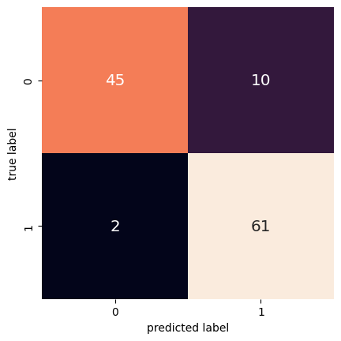

```python
# BEGIN SOLUTION
clf_custom.fit(X_train, y_train)
y_pred_custom = clf_custom.predict(X_test)
mat_custom = confusion_matrix(y_test, y_pred_custom)
fig_custom, ax_custom = plt.subplots()
sns.heatmap(mat_custom, annot=True, cbar=False, ax=ax_custom, fmt="g", square=True, annot_kws={"fontsize": "x-large"},
            xticklabels=clf_custom["classifier"].classes_, yticklabels=clf_custom["classifier"].classes_)
ax_custom.set(xlabel="predicted label", ylabel="true label")
# END SOLUTION
```

```python
# BEGIN SOLUTION
1 - clf_custom.score(X_test, y_test)
# END SOLUTION
```

```
0.10169491525423724
```

#### e) Perform QDA on the training data in order to predict `mpg01` using the variables that seemed most associated with `mpg01` in (b). What is the test error of the model obtained?

```python
# BEGIN SOLUTION
categorical_features_custom = ["origin"]
categorical_transformer_custom = Pipeline([("onehot", OneHotEncoder(drop="first"))])
numerical_features_custom = ["cylinders", "displacement", "horsepower", "weight", "year"]
preprocessor_custom = ColumnTransformer([("cat", categorical_transformer_custom, categorical_features_custom),
                                         ("num", "passthrough", numerical_features_custom)])
clf_custom = Pipeline([("preprocessor", preprocessor_custom), ("classifier", QuadraticDiscriminantAnalysis())])
# END SOLUTION
```

```
0.09322033898305082
```

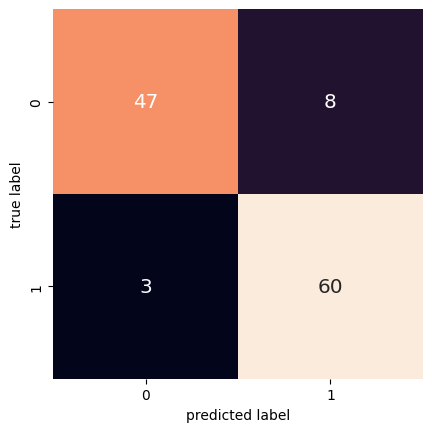

```python
 # BEGIN SOLUTION
clf_custom.fit(X_train, y_train)
y_pred_custom = clf_custom.predict(X_test)
mat_custom = confusion_matrix(y_test, y_pred_custom)
fig_custom, ax_custom = plt.subplots()
sns.heatmap(mat_custom, annot=True, cbar=False, ax=ax_custom, fmt="g", square=True, annot_kws={"fontsize": "x-large"},
            xticklabels=clf_custom["classifier"].classes_, yticklabels=clf_custom["classifier"].classes_)
ax_custom.set(xlabel="predicted label", ylabel="true label")
1 - clf_custom.score(X_test, y_test)
# END SOLUTION
```

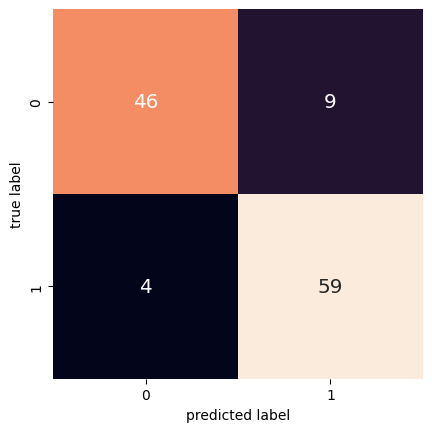

```python
# BEGIN SOLUTION
categorical_features = []
categorical_transformer = Pipeline([("onehot", OneHotEncoder(drop = "first"))])
numerical_features = ["cylinders", "displacement", "horsepower", "weight"]
preprocessor = ColumnTransformer([("cat", categorical_transformer, categorical_features),
                                 ("num", "passthrough", numerical_features)])
clf = Pipeline([("preprocessor", preprocessor), ("classifier", QuadraticDiscriminantAnalysis())])
clf.fit(X_train, y_train)
y_pred = clf.predict(X_test)
mat = confusion_matrix(y_test, y_pred)
fig, ax = plt.subplots()
sns.heatmap(mat, annot = True, cbar = False, ax = ax, fmt = "g", square = True, annot_kws = {"fontsize": "x-large"},
           xticklabels = clf["classifier"].classes_, yticklabels = clf["classifier"].classes_)
ax.set(xlabel = "predicted label", ylabel = "true label");
# END SOLUTION
```

```python
# BEGIN SOLUTION
1 - clf.score(X_test, y_test)
# END SOLUTION
```

```
0.11016949152542377
```

#### f) Perform logistic regression on the training data in order to predict `mpg01` using the variables that seemed most associated with `mpg01` in (b). What is the test error of the model obtained?

Link to linear model: https://scikit-learn.org/stable/modules/generated/sklearn.linear_model.LogisticRegression.html

```
[Text(0.5, 23.52222222222222, 'predicted label'),
```

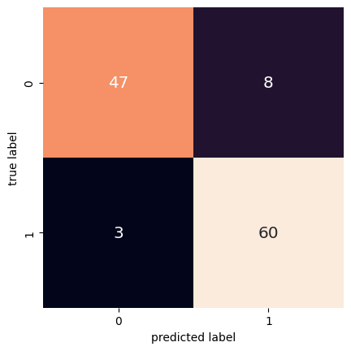

```python
# BEGIN SOLUTION
categorical_features_new = ["origin"]
categorical_transformer_new = Pipeline([("onehot", OneHotEncoder(drop="first"))])
numerical_features_new = ["cylinders", "displacement", "horsepower", "weight", "year"]
preprocessor_new = ColumnTransformer([("cat", categorical_transformer_new, categorical_features_new),
                                      ("num", "passthrough", numerical_features_new)])
clf_new = Pipeline([("preprocessor", preprocessor_new),
                    ("classifier", LogisticRegression(penalty="none", solver="lbfgs"))])

clf_new.fit(X_train, y_train)
y_pred_new = clf_new.predict(X_test)
mat_new = confusion_matrix(y_test, y_pred_new)
fig_new, ax_new = plt.subplots()
sns.heatmap(mat_new, annot=True, cbar=False, ax=ax_new, fmt="g", square=True,
            annot_kws={"fontsize": "x-large"}, xticklabels=clf_new["classifier"].classes_,
            yticklabels=clf_new["classifier"].classes_)
ax_new.set(xlabel="predicted label", ylabel="true label")
# END SOLUTION
```

```python
# BEGIN SOLUTION
1 - clf_new.score(X_test, y_test)
# END SOLUTION
```

```
0.09322033898305082
```

Logistic regression, predicting mpg_med from cylinders, displacement, horsepower, weight, year, and origin yielded a test error of 9.32% consistent with errors from other methods explored.

```
[Text(0.5, 23.52222222222222, 'predicted label'),
```

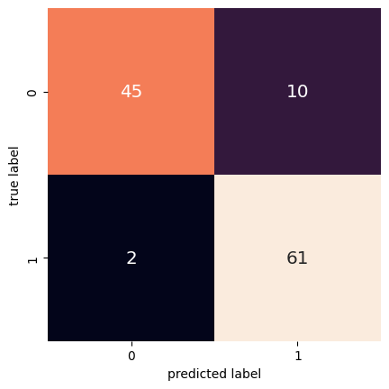

```python
# BEGIN SOLUTION
categorical_features_new = []
categorical_transformer_new = Pipeline([("onehot", OneHotEncoder(drop="first"))])
numerical_features_new = ["cylinders", "displacement", "horsepower", "weight"]
preprocessor_new = ColumnTransformer([("cat", categorical_transformer_new, categorical_features_new),
                                      ("num", "passthrough", numerical_features_new)])
clf_new = Pipeline([("preprocessor", preprocessor_new),
                    ("classifier", LogisticRegression(penalty="none", solver="lbfgs", max_iter=500))])
clf_new.fit(X_train, y_train)
y_pred_new = clf_new.predict(X_test)
mat_new = confusion_matrix(y_test, y_pred_new)
fig_new, ax_new = plt.subplots()
sns.heatmap(mat_new, annot=True, cbar=False, ax=ax_new, fmt="g", square=True,
            annot_kws={"fontsize": "x-large"}, xticklabels=clf_new["classifier"].classes_,
            yticklabels=clf_new["classifier"].classes_)
ax_new.set(xlabel="predicted label", ylabel="true label")
# END SOLUTION
```

```python
# BEGIN SOLUTION
1 - clf_new.score(X_test, y_test)
# END SOLUTION
```

```
0.10169491525423724
```